# Chapter 9-11 exercises - r4ds

Chris Sirico

9/30/2017

## 10.5 Exercises

1. **How can you tell if an object is a tibble? (Hint: try printing `mtcars`, which is a regular data frame).**

Print and observe whether output includes “`A tibble:`” Or use `class(objectName)`. For a tibble, returns: `[1] "tbl_df" "tbl" "data.frame"`

2. **Compare and contrast the following operations on a `data.frame` and equivalent tibble. What is different? Why might the default data frame behaviours cause you frustration?**

```
df <- data.frame(abc = 1, xyz = "a")
df$x
df[, "xyz"]
df[, c("abc", "xyz")]
```

```
# my code:
dtbl <- tibble(abc = 1, xyz = "a")
dtbl$x
dtbl[, "xyz"]
dtbl[, c("abc", "xyz")]
```

`df$x` returns the second column as a partial match for the data frame. The same command returns an error on the tibble–must specify exact column name.

`df[, "xyz"]` This more specific form of column call returns the column for both types of objects.

`df[, c("abc", "xyz")]` Passing a character vector of column names prints those columns for both object types.

3. **If you have the name of a variable stored in an object, e.g. `var <- "mpg"`, how can you extract the reference variable from a tibble?**

Double brackets with the variable name and no quotes will do it: `tibbleName[[var]]`

4. **Practice referring to non-syntactic names in the following data frame by:**
1. Extracting the variable called 1.
2. Plotting a scatterplot of 1 vs 2.
3. Creating a new column called 3 which is 2 divided by 1.
4. Renaming the columns to one, two and three.

```r
annoying[[1]]
```

```
##  [1]  1  2  3  4  5  6  7  8  9 10
```

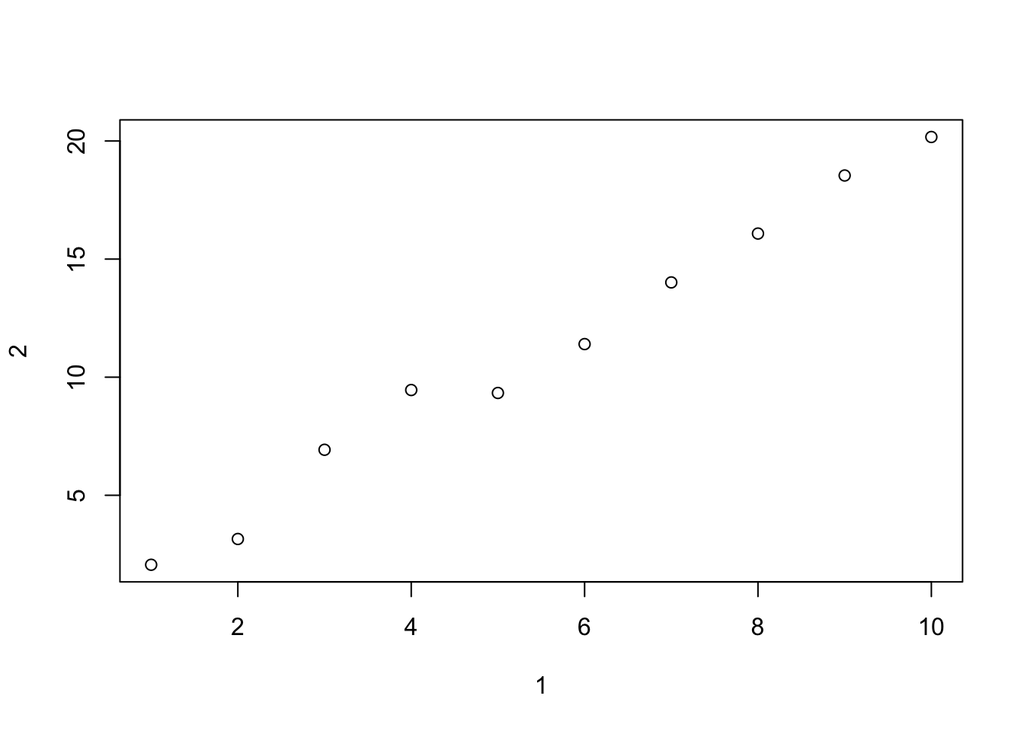

```r
plot (annoying)
```

```r
annoying <- mutate(annoying, "3" = annoying[[2]] / annoying[[1]])
```

```r
transmute(annoying, one = annoying[[1]], two = annoying[[2]], three = annoying[[3]])
```

```
## # A tibble: 10 x 3
##      one       two    three
##    <int>     <dbl>    <dbl>
##  1     1  2.058427 2.058427
##  2     2  3.150186 1.575093
##  3     3  6.927022 2.309007
##  4     4  9.456554 2.364138
##  5     5  9.331795 1.866359
##  6     6 11.401047 1.900175
##  7     7 14.012697 2.001814
##  8     8 16.081227 2.010153
##  9     9 18.538932 2.059881
## 10    10 20.169078 2.016908
```

5. **What does `tibble::enframe()` do? When might you use it?** It takes a one-dimensional (so-called “atomic”) vector and returns a two-column tibble with a `name` column and corresponding `value` column. The vector input can have elements in the form `c(a = 1, b = 2)`, where `a` and `b` become names and `1` and `2` become values.

I could see this being used to store name / attribute pairs from JSON data.

6. **What option controls how many additional column names are printed at the footer of a tibble?**

`options(tibble.print_max = n)`

## 11.2.2 Exercises

1. **What function would you use to read a file where fields were separated with “|”?**

`read_delim()`

2. **Apart from `file`, `skip`, and `comment`, what other arguments do `read_csv()` and `read_tsv()` have in common?**

`col_names, col_types, locale, na, quoted_na, quote, trim_ws, n_max, guess_max, progress`

3. **What are the most important arguments to `read_fwf()`?**

`file`, `col_names`

4. **Sometimes strings in a CSV file contain commas. To prevent them from causing problems they need to be surrounded by a quoting character, like " or ’. By convention, `read_csv()` assumes that the quoting character will be “, and if you want to change it you’ll need to use read_delim() instead. What arguments do you need to specify to read the following text into a data frame? `"x,y\n1,'a,b'"`

`df <- read_delim("x,y\n1,'a,b'", quote = "'", delim = ",")`

5. **Identify what is wrong with each of the following inline CSV files. What happens when you run the code?**

   ```
   read_csv("a,b\n1,2,3\n4,5,6") #only 2 column headers but 3 columns of data; extra values truncated
   read_csv("a,b,c\n1,2\n1,2,3,4") #inconsistent number of columns; truncation and NA empties
   read_csv("a,b\n\"1") #missing value, extra backslash, missing/extra "
   read_csv("a,b\n1,2\na,b") #works beautifully
   read_csv("a;b\n1;3") #missing: delim = ";"
   ```

## 11.3.5 Exercises

1. **What are the most important arguments to `locale()`?**

`decimal_mark` is the most important. `encoding`, `date_format` are also important.

2. **What happens if you try and set decimal_mark and grouping_mark to the same character? What happens to the default value of grouping_mark when you set decimal_mark to “,”? What happens to the default value of decimal_mark when you set the grouping_mark to “.”?**

R throws an error if `decimal_mark` and `grouping_mark` are set to the same value: `Error:`decimal_mark`and`grouping_mark`must be different`. If you set one value to comma, the other will default to period and vice versa.

3. **I didn’t discuss the date_format and time_format options to locale(). What do they do? Construct an example that shows when they might be useful.**

`date_format` allows reconversions to various configurations of Year / Month / Day. I’d guess `time_format` allows conversion between 12- and 24-hour timetelling.

`parse_date("17 Aprile 1988", "%d %B %Y", locale = locale("it")) #> [1] "1988-04-17"`

4. **If you live outside the US, create a new locale object that encapsulates the settings for the types of file you read most commonly.**

Looks like being born in the US has provided yet perk.

5. **What’s the difference between read_csv() and read_csv2()?**

CSV2 format uses semicolons as delimiters. Often used in countries where the comma functions as the decimal mark. This function reads in data with the corresponding settings as the default.

6. **What are the most common encodings used in Europe? What are the most common encodings used in Asia? Do some googling to find out.**

ASCII is common in Europe. Big5 and GB18030 for China. Shift-JIS for Japanese. UTF-8 is used everywhere.

7. **Generate the correct format string to parse each of the following dates and times:**

```
d1 <- "January 1, 2010"
d2 <- "2015-Mar-07"
d3 <- "06-Jun-2017"
d4 <- c("August 19 (2015)", "July 1 (2015)")
d5 <- "12/30/14" # Dec 30, 2014
t1 <- "1705"
t2 <- "11:15:10.12 PM"
```

```
d1 <- parse_date("January 1, 2010", "%B %d, %Y")
d2 <- parse_date("2015-Mar-07", "%Y-%b-%d")
d3 <- parse_date("06-Jun-2017", "%d-%b-%Y")
d4 <- parse_date(c("August 19 (2015)", "July 1 (2015)"), "%B %d (%Y)")
d5 <- read_delim("12/30/14 # Dec 30, 2014", delim = "#", "%m/%d/%y") # This one has me stumped.
t1 <- parse_time("1705", "%H%M")
t2 <- parse_time("11:15:10.12 PM", "%H:%M:%OS %p")
```

*Keeping below content for my own reference*